```python
%matplotlib inline
import matplotlib.pyplot as plt
import matplotlib.patches as mpatches
from nilearn import plotting as ni_plt
import altair as alt
# Use this for large dataframes. But be smart!!
alt.data_transformers.disable_max_rows()
from altair import datum
from IPython.display import Image

import pandas as pd
import numpy as np
```

# Exploring Brain Activity During Movement

For this exploration, I chose to look at brain data from my lab during arm movement. This data was collected from 12 ECoG patients undergoing epilepy monitoring at Harborview Medical Hospital in Seattle. Both video and brain data were recorded during their 7-9 day hospital stay. The video data was then used to generate data on movement events. Here, I explore what the brain signal looks like across patients, and on average, during different types of arm movements. The main questions I hope to answer are:

1. What does the brain activity look like on average during arm movements?
2. How does brain activity vary per person during arm movements?
3. How does brain activity vary across different regions of the brain?
4. How does brain activity change during specific types of arm movements, such as upward or downward movements?

More details about this dataset can be found in this paper: https://arxiv.org/abs/2001.08349

First, let us set some parameters and load in the data. These parameters will make more sense as we explore the data.

```python
ROIs_of_interest = [47]
```

```python
# movement_power_df = pd.read_csv('move_rest_avg_and_per_all_ROIs_power_spec.csv')
roi_pos_good_df = pd.read_csv('ROI_coords.csv')
hist_bin_df = pd.read_csv("reach_angle_histogram.csv")
reach_pca_time_df = pd.read_csv('reach_pca_time_direction_4components.csv')
```

## 1. What does brain activity look like on average during arm movements?

One way we can answer this question, is by looking at a spectrogram (visualization of the frequency spectrum through time) of brain activity during movement. This will show how different frequnecies may become more or less active when movement occurs

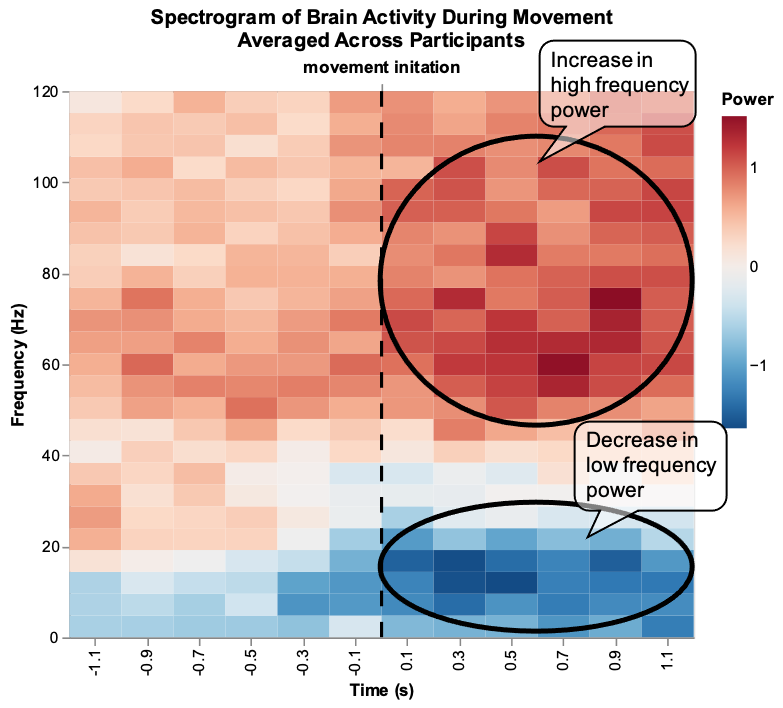

```python
Image(filename='annotated_figures/avg_movement_annotated.png')
```

Here we see a spectrogram that shows how the power (or activity) of different frequency bands during movement averaged across all participants. We can see an increase in power for high frequencies, and a decrease in lower frequencies, once movement is initated, as expected from the neuroscience literature.

# 2. How does brain activity vary per person during movement?

So far, we have seen the average brain activity during movement, but can we explore how different people's brains change during movement? To do this, we can create spectrograms for each participant.

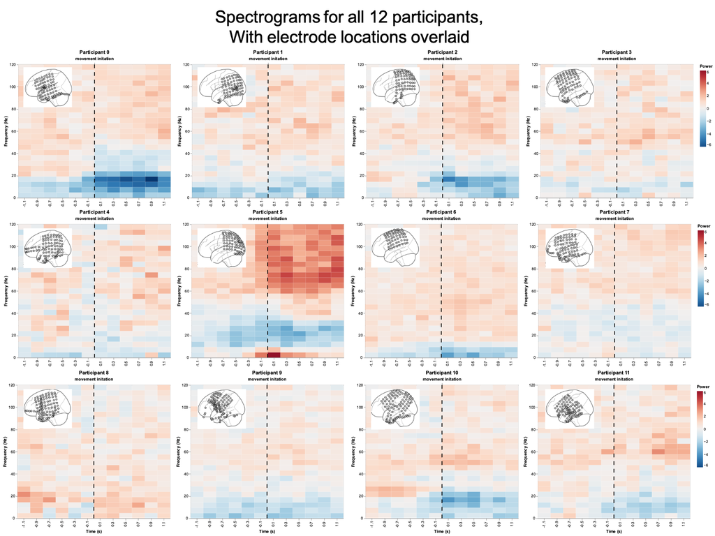

```python
Image(filename='annotated_figures/per_sbj_movement_annotated.png')
```

We can see that participant electrode locations (places where brain activity was recorded) vary across participants, as well as the changes in the frequency bands. Surprisingly, participants with more motor coverage do not always show clearer signals in the frequency domain during movement, but Participant 5 shows a strong signal and has a good amount of motor coverage.

# 3. How does brain activity during movement vary across brain areas?

So far we have seen that brain activity tends to see increased power in high frequency bands, and decreased power in low frequencies during movement. But so far we have actually only looked at activity in one region of the brain! So where have we been exploring brain activity so far?

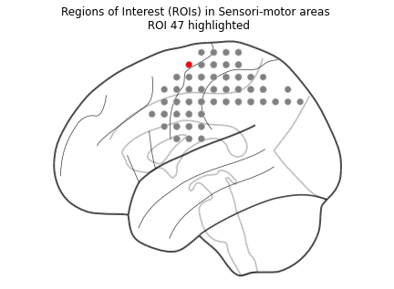

```python
node_size = 50
sides_2_display = 'l'
num_electrodes = len(ROIs_of_interest)

colors = ['grey' for roi in roi_pos_good_df.iterrows()]
for i, c in enumerate(colors):
    if i in ROIs_of_interest:
        colors[i] = 'red'

fig,ax=plt.subplots(1,1, figsize=(7.5,5))
ax.set_title('Regions of Interest (ROIs) in Sensori-motor areas \n ROI 47 highlighted')
ni_plt.plot_connectome(np.eye(roi_pos_good_df.shape[0]), roi_pos_good_df, output_file=None,
                               node_kwargs={'alpha': 1, 'edgecolors': 'silver','linewidths':.5,'marker': 'o'},
                               node_size=node_size, node_color=colors,display_mode=sides_2_display, axes = ax)
ni_plt.show()
```

We can see that the part of the brain we were looking at activity from is located in the primary motor cortex. It is not surprising then that on average activity in this area changes with movement.

## What other brain regions can we look at?

To explore how brain activity looks in different regions, lets pick a few different ROIs that cover different parts of the sensorimotor region to explore

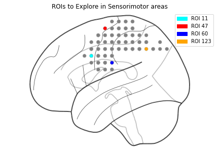

```python
ROIs_of_interest = [11, 47, 60, 123]
ROI_colors = {11:"aqua", 47:"red", 60: "blue", 123: "orange"}

colors = ['grey' for roi in roi_pos_good_df.iterrows()]
for i, c in enumerate(colors):
    if i in ROIs_of_interest:
        colors[i] = ROI_colors[i]

ROI_patches = []
for roi in ROIs_of_interest:
    ROI_patches.append(mpatches.Patch(color=ROI_colors[roi], label='ROI '+str(roi)) )

fig,ax=plt.subplots(1,1, figsize=(7.5,5))
ax.set_title('ROIs to Explore in Sensorimotor areas')
ax.legend(handles=ROI_patches)
ni_plt.plot_connectome(np.eye(roi_pos_good_df.shape[0]), roi_pos_good_df, output_file=None,
                               node_kwargs={'alpha': 1, 'edgecolors': 'silver','linewidths':.5,'marker': 'o'},
                               node_size=node_size, node_color=colors,display_mode=sides_2_display, axes=ax)

fig.show()
```

Now that we've picked a few regions to explore, we can create new average spectrograms for each ROI and see how they compare

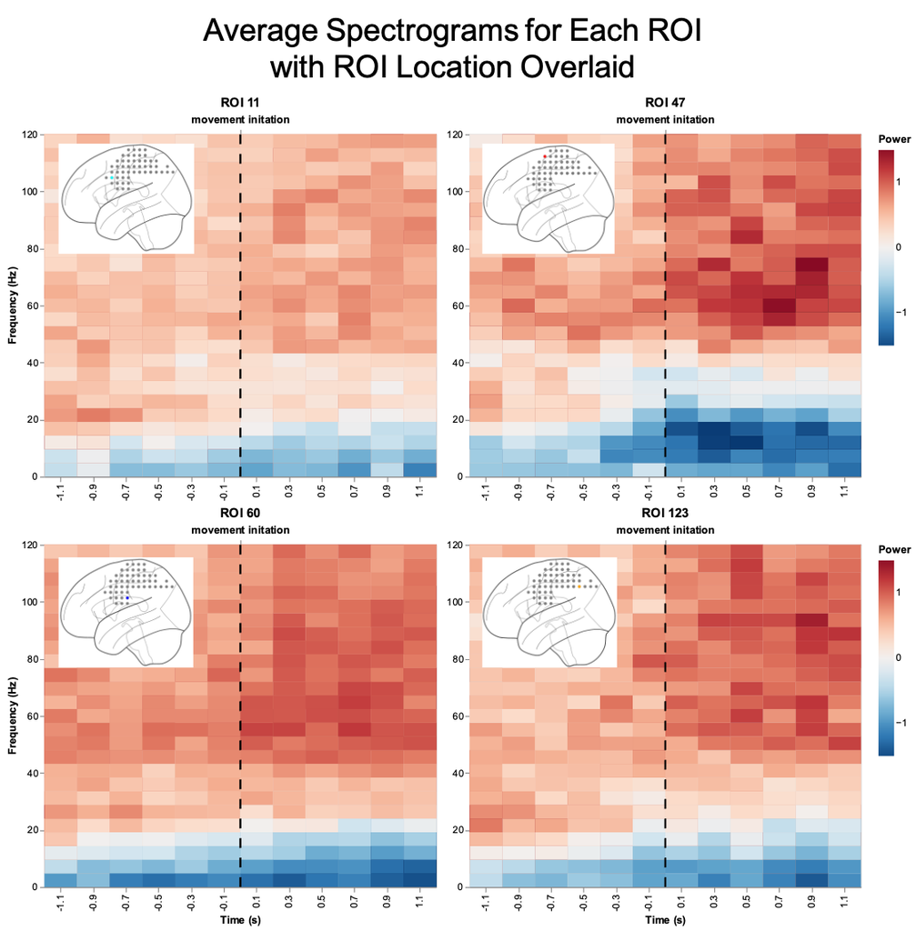

```python
Image(filename='annotated_figures/per_ROI_movement_annotated.png')
```

From this figure we can see that ROI 47 has the expected changes in high and low frequencies at movement initation, whereas the other ROIs are less clear. ROI 123 does seem to have an increase in power in high frequencies at least. Thus, it made sense that our data initally looked at ROI 47.

## How does individual variance look in other sensorimotor areas?

To drill down a little deeper, we can also look at individual brain activity in a new area. Since ROI 123 showed the expected increase in power for high frequencies, we can look here.

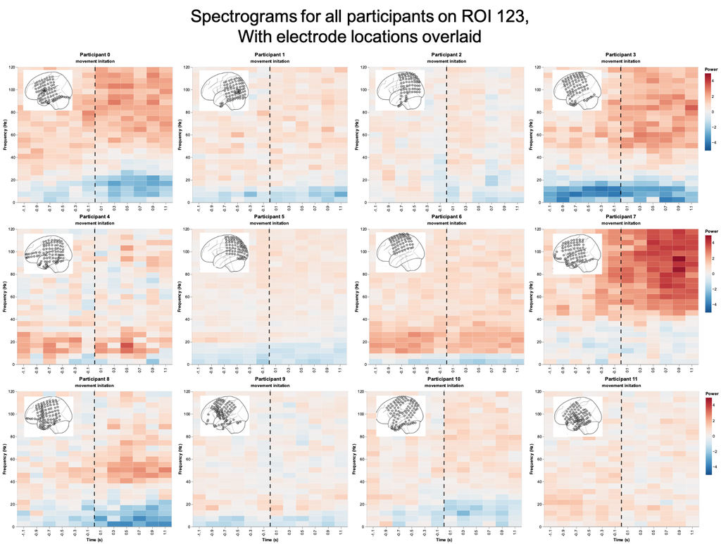

```python
Image(filename='annotated_figures/ROI123_per_sbj_power_annotated.png')
```

Drilling down, we see that there is still a lot of variance in individual participant brain signals during movement, with Participant 0, 3, and 7 really driving the power increase in the higher frequencies that we saw. We also see that Participant 5 no longer has a very strong signal when we change the region we are looking at activity from.

# 4. How does brain activity change during specific types of arm movements, such as upward or downward movements?

So far, we have just looked at arm movements in general, but is this averaging hiding interesting activity that is happening for specific types of movements? To explore this further, we will dive into one aspect of the movements, reach angle.

First, lets explore what reach angles are most common in the dataset.

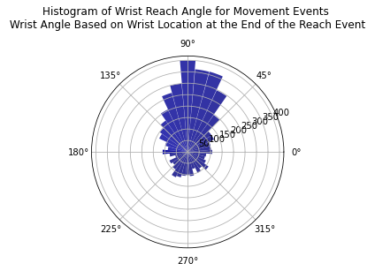

```python
N = len(hist_bin_df['Bins'])
bottom = 0
max_height = 4

width = (2*np.pi) / N

ax = plt.subplot(111, polar=True)
bars = ax.bar(hist_bin_df['Bins'], hist_bin_df['Counts'], width=width, bottom=bottom)

# Use custom colors and opacity
for r, bar in zip(hist_bin_df['Bins'], bars):
    bar.set_facecolor(plt.cm.jet(r / 100.))
    bar.set_alpha(0.8)

plt.title('Histogram of Wrist Reach Angle for Movement Events \n Wrist Angle Based on Wrist Location at the End of the Reach Event \n')
plt.show()
```

We can see that a large majority of the wrist angles during these movement events are around 90 degrees, which makes sense considering that people often touch their face or use their hands for eating.